# Empirical Application: Healthcare Example from Obermeyer et al. (2019)

### Testing $\mathsf{H}_0$: $\mathcal{E}$ is Weak Group-Skewed

```
## [1] "H_0: WEAK GROUP SKEW fails to be rejected"
```

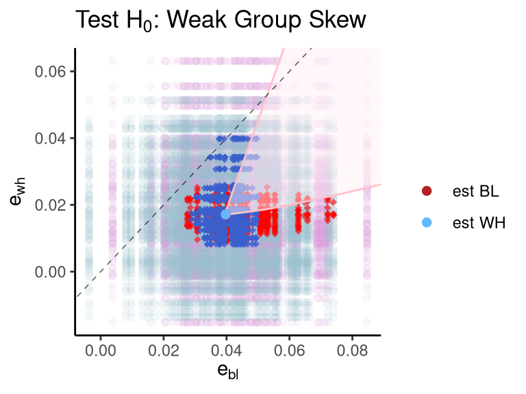

```r
### RECALL R=BL, B=WH
## first, construct confidence sets for (R, B)
# define parameter space of (R, B) by using the estimated R and B
num_grid <- 100 # (num_grid)^2 is number of parameter values being tested
# candidate values for R
grid_R <- data.matrix(expand.grid(rnorm(num_grid,
                                        mean=plot_RBFvert[1,1],
                                        sd=kappa_n),
                                  rnorm(num_grid,
                                        mean=plot_RBFvert[1,2],
                                        sd=kappa_n)))

grid_R <- rbind(c(plot_RBFvert[1,1], plot_RBFvert[1,2]),
                grid_R)

# candidate values for B
grid_B <- data.matrix(expand.grid(rnorm(num_grid,
                                        mean=plot_RBFvert[2,1],
                                        sd=kappa_n),
                                  rnorm(num_grid,
                                        mean=plot_RBFvert[2,2],
                                        sd=kappa_n)))

grid_B <- rbind(c(plot_RBFvert[2,1], plot_RBFvert[2,2]),
                grid_B)

# test under the presence of kinks
test1 <- CS_RB(X=X, G=G, Y=Y,
               est_nuisance=est_nuisance,
               R1=grid_R[,1],
               R2=grid_R[,2],
               B1=grid_B[,1],
               B2=grid_B[,2],
               optimizer="grid", grid_size=1000,
               kink=TRUE, num_bstp_rep=1000)

# set of indices of candidate (R,B) not rejected
CS_index <- which(test1$rej==0)
# result of the test, as per Step 2, Procedure 1 of Liu & Molinari (2024)
test1_rej <- max((grid_R[CS_index,1]-grid_R[CS_index,2])*(grid_B[CS_index,1]-grid_B[CS_index,2])) < 0
```

Note: Plum-colored (resp., grayish-blue-colored) circles correspond to candidate values for $BL$ ($WH$), and red (blue) diamonds correspond to accepted candidate values for $BL$ ($WH$).

### Testing $\mathsf{H}_0$: There Is No LDA to $e^*$

```r
## import predictions from the 3 experimental algorithms trained in Obermeyer et al. (2019)
# experimental algorithm that predicts total cost
pred_tc <- read.csv("../../../data/pred_log_cost_df.csv")
alg_tc <- as.numeric(pred_tc$log_cost_t_hat > quantile(pred_tc$log_cost_t_hat, 0.97))
# experimental algorithm that predicts avoidable cost
pred_ac <- read.csv("../../../data/pred_log_cost_avoidable_df.csv")
alg_ac <- as.numeric(pred_ac$log_cost_avoidable_t_hat > quantile(pred_ac$log_cost_avoidable_t_hat, 0.97))
# experimental algorithm that predicts number of active chronic conditions
pred_acc <- read.csv("../../../data/pred_gagne_sum_t_df.csv")
alg_acc <- as.numeric(pred_acc$gagne_sum_t_hat > quantile(pred_acc$gagne_sum_t_hat, 0.97))

# the original algorithm that returns risk scores
alg_orig <- as.numeric(df$risk_score_t > quantile(df$risk_score_t, 0.97))

test2 <- test_LDA(target_alg_preds=rbind(alg_orig, alg_tc, alg_ac, alg_acc),
                  X=X, G=G, Y=Y,
                  est_nuisance=est_nuisance,
                  num_bstp_rep=1000,
                  optimizer="grid",
                  kink=TRUE)
```

[output not shown]

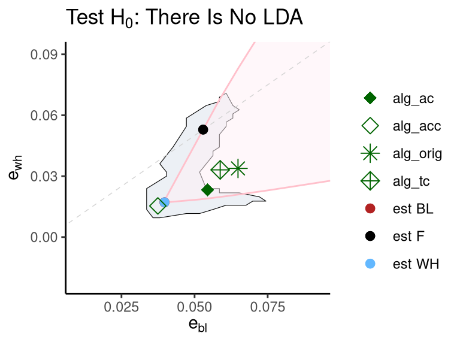

```
## [1] "Test Null: There Is No LDA"
```

```
## [1] "Algorithm   Risk Allocation    Test Statistic    Critical Value   Reject"
```

```
## [1] " alg_orig    (0.065, 0.034)         3.767            1.885        TRUE"
```

```
## [1] "  alg_tc     (0.059, 0.033)         2.753            1.948        TRUE"
```

```
## [1] "  alg_ac     (0.054, 0.023)         1.428            1.732        FALSE"
```

```
## [1] " alg_acc     (0.037, 0.015)         0.541            1.642        FALSE"
```

### Constructing Confidence Sets for the Distance to the Fairest Point $F$

```r
# squared Euclidean distance
rho <- function(a1, a2, b1, b2) {
  return((a1-b1)^2+(a2-b2)^2)
}

## the original algorithm that returns risk scores ---
# create parameter space of candidate (e, F)
cand_eF_orig <- create_candidate_eF(X=X, G=G, Y=Y,
                                    est_nuisance=est_nuisance,
                                    est_F45_coord=F45,
                                    num_grid=10000,
                                    alg_preds=alg_orig,
                                    optimizer="BFGS",
                                    buffer=4*kappa_n)
# only take non-negative candidate (e, F)
nonneg_ind <- sample(which(cand_eF_orig$cand_F_cross[,1] > 0 & cand_eF_orig$cand_e_cross[,1] > 0 & cand_eF_orig$cand_e_cross[,2] > 0), size=3000)
cand_eF_orig <- list("cand_F_cross"=cand_eF_orig$cand_F_cross[nonneg_ind, ],
                     "cand_e_cross"=cand_eF_orig$cand_e_cross[nonneg_ind, ])
# only the cross case matters, as `create_candidate_eF` returns NULL for the above and below case after then kappa_n adjustment
test3_orig <- CS_eF_cross(target_alg_preds=matrix(alg_orig, nrow=1),
                          X=X, G=G, Y=Y,
                          est_nuisance=est_nuisance,
                          F1=c(F45, cand_eF_orig$cand_F_cross[,1]),
                          F2=c(F45, cand_eF_orig$cand_F_cross[,2]),
                          e1=matrix(c(e_orig[1], cand_eF_orig$cand_e_cross[,1]), nrow=1),
                          e2=matrix(c(e_orig[2], cand_eF_orig$cand_e_cross[,2]), nrow=1),
                          num_bstp_rep=1000,
                          dist_func="euclidean-sq",
                          optimizer="BFGS",
                          kink=TRUE)

# CS_n^{\rho(e^*, F)}
CS_orig <- cbind(rbind(c(F45, F45), cand_eF_orig$cand_F_cross)[which(test3_orig$rej==0), , drop=FALSE],
                 rbind(e_orig, cand_eF_orig$cand_e_cross)[which(test3_orig$rej==0), , drop=FALSE])
# retrieving distances
CS_dist_orig <- c(min(rho(CS_orig[,1], CS_orig[,2], CS_orig[,3], CS_orig[,4])),
                  max(rho(CS_orig[,1], CS_orig[,2], CS_orig[,3], CS_orig[,4])))


## the experimental algorithm that predicts total cost ---
# create parameter space of candidate (e, F)
cand_eF_tc <- create_candidate_eF(X=X, G=G, Y=Y,
                                  est_nuisance=est_nuisance,
                                  est_F45_coord=F45,
                                  num_grid=10000,
                                  alg_preds=alg_tc,
                                  optimizer="grid",
                                  buffer=4*kappa_n)
# only take non-negative candidate (e, F)
nonneg_ind <- sample(which(cand_eF_tc$cand_F_cross[,1] > 0 & cand_eF_tc$cand_e_cross[,1] > 0 & cand_eF_tc$cand_e_cross[,2] > 0), size=3000)
cand_eF_tc <- list("cand_F_cross"=cand_eF_tc$cand_F_cross[nonneg_ind, ],
                   "cand_e_cross"=cand_eF_tc$cand_e_cross[nonneg_ind, ])
# only the cross case matters, as `create_candidate_eF` returns NULL for the above and below case after then kappa_n adjustment
test3_tc <- CS_eF_cross(target_alg_preds=matrix(alg_tc, nrow=1),
                        X=X, G=G, Y=Y,
                        est_nuisance=est_nuisance,
                        F1=c(F45, cand_eF_tc$cand_F_cross[,1]),
                        F2=c(F45, cand_eF_tc$cand_F_cross[,2]),
                        e1=matrix(c(e_tc[1], cand_eF_tc$cand_e_cross[,1]), nrow=1),
                        e2=matrix(c(e_tc[2], cand_eF_tc$cand_e_cross[,2]), nrow=1),
                        num_bstp_rep=1000,
                        dist_func="euclidean-sq",
                        optimizer="BFGS",
                        kink=TRUE)

# CS_n^{\rho(e^*, F)}
CS_tc <- cbind(rbind(c(F45, F45), cand_eF_tc$cand_F_cross)[which(test3_tc$rej==0), , drop=FALSE],
               rbind(e_tc, cand_eF_tc$cand_e_cross)[which(test3_tc$rej==0), , drop=FALSE])
# retrieving distances
CS_dist_tc <- c(min(rho(CS_tc[,1], CS_tc[,2], CS_tc[,3], CS_tc[,4])),
                max(rho(CS_tc[,1], CS_tc[,2], CS_tc[,3], CS_tc[,4])))


## the experimental algorithm that predicts avoidable cost ---
# create parameter space of candidate (e, F)
cand_eF_ac <- create_candidate_eF(X=X, G=G, Y=Y,
                                  est_nuisance=est_nuisance,
                                  est_F45_coord=F45,
                                  num_grid=10000,
                                  alg_preds=alg_ac,
                                  optimizer="grid",
                                  buffer=4*kappa_n)
# only take non-negative candidate (e, F)
nonneg_ind <- sample(which(cand_eF_ac$cand_F_cross[,1] > 0 & cand_eF_ac$cand_e_cross[,1] > 0 & cand_eF_ac$cand_e_cross[,2] > 0), size=3000)
cand_eF_ac <- list("cand_F_cross"=cand_eF_ac$cand_F_cross[nonneg_ind, ],
                   "cand_e_cross"=cand_eF_ac$cand_e_cross[nonneg_ind, ])

# only the cross case matters, as `create_candidate_eF` returns NULL for the above and below case after then kappa_n adjustment
test3_ac <- CS_eF_cross(target_alg_preds=matrix(alg_ac, nrow=1),
                        X=X, G=G, Y=Y,
                        est_nuisance=est_nuisance,
                        F1=c(F45, cand_eF_ac$cand_F_cross[,1]),
                        F2=c(F45, cand_eF_ac$cand_F_cross[,2]),
                        e1=matrix(c(e_ac[1], cand_eF_ac$cand_e_cross[,1]), nrow=1),
                        e2=matrix(c(e_ac[2], cand_eF_ac$cand_e_cross[,2]), nrow=1),
                        num_bstp_rep=1000,
                        dist_func="euclidean-sq",
                        optimizer="BFGS",
                        kink=TRUE)

# CS_n^{\rho(e^*, F)}
CS_ac <- cbind(rbind(c(F45, F45), cand_eF_ac$cand_F_cross)[which(test3_ac$rej==0), , drop=FALSE],
               rbind(e_ac, cand_eF_ac$cand_e_cross)[which(test3_ac$rej==0), , drop=FALSE])
# retrieving distances
CS_dist_ac <- c(min(rho(CS_ac[,1], CS_ac[,2], CS_ac[,3], CS_ac[,4])),
                max(rho(CS_ac[,1], CS_ac[,2], CS_ac[,3], CS_ac[,4])))

## the experimental algorithm that predicts active chronic conditions ---
# create parameter space of candidate (e, F)
cand_eF_acc <- create_candidate_eF(X=X, G=G, Y=Y,
                                   est_nuisance=est_nuisance,
                                   est_F45_coord=F45,
                                   num_grid=10000,
                                   alg_preds=alg_acc,
                                   optimizer="grid",
                                   buffer=4*kappa_n)
# only take non-negative candidate (e, F)
nonneg_ind <- sample(which(cand_eF_acc$cand_F_cross[,1] > 0 & cand_eF_acc$cand_e_cross[,1] > 0 & cand_eF_acc$cand_e_cross[,2] > 0), size=3000)
cand_eF_acc <- list("cand_F_cross"=cand_eF_acc$cand_F_cross[nonneg_ind, ],
                    "cand_e_cross"=cand_eF_acc$cand_e_cross[nonneg_ind, ])
# only the cross case matters, as `create_candidate_eF` returns NULL for the above and below case after then kappa_n adjustment
test3_acc <- CS_eF_cross(target_alg_preds=matrix(alg_acc, nrow=1),
                         X=X, G=G, Y=Y,
                         est_nuisance=est_nuisance,
                         F1=c(F45, cand_eF_acc$cand_F_cross[,1]),
                         F2=c(F45, cand_eF_acc$cand_F_cross[,2]),
                         e1=matrix(c(e_acc[1], cand_eF_acc$cand_e_cross[,1]), nrow=1),
                         e2=matrix(c(e_acc[2], cand_eF_acc$cand_e_cross[,2]), nrow=1),
                         num_bstp_rep=1000,
                         dist_func="euclidean-sq",
                         optimizer="BFGS",
                         kink=TRUE)

# CS_n^{\rho(e^*, F)}
CS_acc <- cbind(rbind(c(F45, F45), cand_eF_acc$cand_F_cross)[which(test3_acc$rej==0), , drop=FALSE],
                rbind(e_acc, cand_eF_acc$cand_e_cross)[which(test3_acc$rej==0), , drop=FALSE])
# retrieving distances
CS_dist_acc <- c(min(rho(CS_acc[,1], CS_acc[,2], CS_acc[,3], CS_acc[,4])),
                 max(rho(CS_acc[,1], CS_acc[,2], CS_acc[,3], CS_acc[,4])))
```

Note: Light-green (resp., light-gray) circles correspond to candidate values for $e^*$ ($F$), and green (yellow) diamonds correspond to accepted candidate values for $e^*$ ($F$). The estimated $F$ (yellow circle) plotted in the figure below is the one obtained using Eq. (20) and different from the estimated $F$ (black circle) plotted in the previous figures, which is the fairest point corresponding to the estimated feasible set using Eq. (26). The distance-to-F test as described in Section 7 uses the yellow $F$.

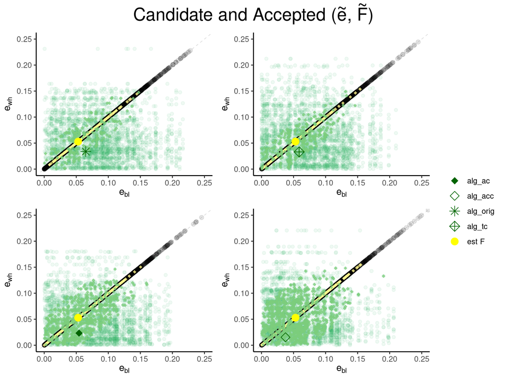

```
## [1] "Confidence Sets for the Squared-Euclidean Distance to F:"
```

```
## [1] "Estimated F: (0.049, 0.049)"
```

```
## [1] "Algorithm     Risk Allocation    Estimated Distance    Confidence Set"
```

```
## [1] " alg_orig     (0.065, 0.034)          0.0005           (0.000, 0.001)"
```

```
## [1] " alg_tc       (0.059, 0.033)          0.0004           (0.000, 0.001)"
```

```
## [1] " alg_ac       (0.054, 0.023)          0.0007           (0.000, 0.002)"
```

```
## [1] " alg_acc      (0.037, 0.015)          0.0013           (0.000, 0.003)"
```